# Discription

- The dataset provides monthly total number of a US airline passengers from 1949 to 1960.
- It contains 2 columns:

  ```
    1. Month
    2. Passengers: number of passengers in this month
  ```

- We Will use this data as *Time-Series* and use previous months data to predict the number of passenger of the next one.
- Applying LSTM model to use 2 months data to predict the next one.

```python
import pandas as pd
import numpy as np
import matplotlib.pyplot as plt
from tensorflow.keras.layers import Dense,LSTM
from tensorflow.keras.models import Sequential
from sklearn.preprocessing import MinMaxScaler
```

# Impoting Data

```python
#"C:\Users\Afnan\Downloads\AirPassengers.csv"
data = pd.read_csv("C:/Users/Afnan/Downloads/AirPassengers.csv")
data.head()
```

|  | Month | #Passengers |
| --- | --- | --- |
| 0 | 1949-01 | 112 |
| 1 | 1949-02 | 118 |
| 2 | 1949-03 | 132 |
| 3 | 1949-04 | 129 |
| 4 | 1949-05 | 121 |

# Prepocessing

> fix the column name to be easier for use

```python
data.rename(columns={'#Passengers':'passengers'},inplace=True)
```

> **Month** column can be dropped as is a *Time-Series* Model

```python
data = data['passengers']
```

```python
type(data)
```

```
pandas.core.series.Series
```

> Convet data type into *2D array* to be able to apply methods

```python
data = np.array(data).reshape(-1,1)
type(data)
```

```
numpy.ndarray
```

data is converted and reshaped as it had 1 feature

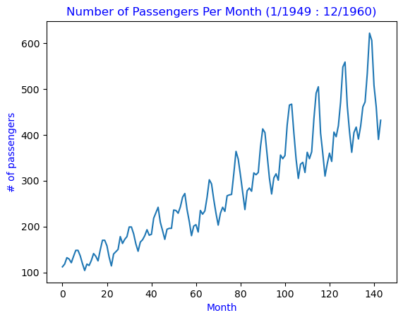

```python
plt.plot(data)
plt.title('Number of Passengers Per Month (1/1949 : 12/1960)' , color='blue')
plt.xlabel('Month', color='blue')
plt.ylabel('# of passengers', color='blue')
plt.show()
```

We can see The *Patterns* and *Seasons effects*

# Scalling

> As LSTM is senstive to the scale of the data  
> we will normalize (rescale to the range 0:1 ) it Using MinMax

```python
scaler = MinMaxScaler()
data = scaler.fit_transform(data)
```

```python
len(data)
```

```
144
```

> Let Split into *70%* about **100 training and 44 testing**

```python
train = data[0:100,:]
test = data[100:,:]
```

# Set the Model Input

- For LSTM we need sequential input for training and testing

  > Defining a function to prepare the data with 2 arguments:
  1. **data:** NumPy array to be converted into the dataset.
  2. **steps:** integer to represent the the previous time "months" steps.

```python
def get_data(data, steps):
    dataX = []
    dataY = []
    for i in range(len(data)-steps-1):
        a = data[i:(i+steps), 0]
        dataX.append(a)
        dataY.append(data[i+steps,0])
    return np.array(dataX), np.array(dataY)
```

[figure not shown]

```python
steps = 2
```

```python
X_train, y_train = get_data(train, steps)

X_test, y_test = get_data(test, steps)
```

> reshape the data to **3D format** as required for LSTM model

```python
X_train = np.reshape(X_train, (X_train.shape[0], 1, X_train.shape[1]))

X_test = np.reshape(X_test, (X_test.shape[0], 1, X_test.shape[1]))
```

# Building the LSTM Model

```python
model = Sequential()
model.add(LSTM(120, input_shape=(1, steps)))
model.add(Dense(65))
model.add(Dense(1))
model.compile(loss = 'mean_squared_error', optimizer = 'adam')
```

```python
model.summary()
```

```
Model: "sequential"
_________________________________________________________________
 Layer (type)                Output Shape              Param #
=================================================================
 lstm (LSTM)                 (None, 120)               59040

 dense (Dense)               (None, 65)                7865

 dense_1 (Dense)             (None, 1)                 66

=================================================================
Total params: 66,971
Trainable params: 66,971
Non-trainable params: 0
_________________________________________________________________
```

# Training the Model

```python
model.fit(X_train, y_train, epochs=25, batch_size=1)
```

```
<keras.callbacks.History at 0x1d0b4499190>
```

# Testing The model

```python
y_pred = model.predict(X_test)
```

> Rescale the prediction's result as the model return scaled ones

```python
y_pred = scaler.inverse_transform(y_pred)
y_test = y_test.reshape(-1,1)
y_test = scaler.inverse_transform(y_test)
```

# Plot Prediction Results

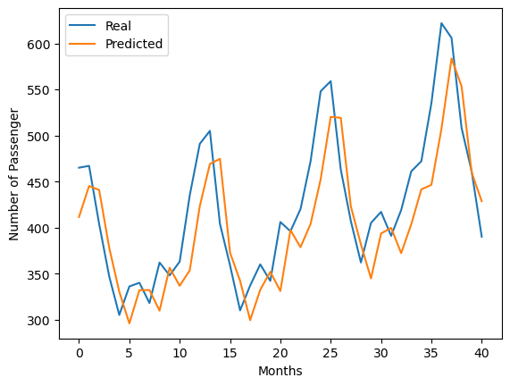

```python
plt.plot(y_test, label = 'Real')
plt.plot(y_pred, label = 'Predicted')
plt.xlabel('Months')
plt.ylabel('Number of Passenger')
plt.legend()
plt.show()
```

> As shown in the plot the model could *catch the pattern* of the Time-series and It was close to exact values at some points.